# Weight of Fish

Jonathan Paul P. Clavio

November 3 2020

```r
Fishdata=read.csv("Fish.csv",header=TRUE)
```

# 1 Introduction

## 1.1 Build the best regression model you can that predicts the weight of perch

## 1.2 Using only two predictor variables

# 2 Methods

We are using numerical~numerical since our two variables we are looking at are all numerical explanatory variables.

#Results

## 2.1 Descriptive Results

### 2.1.1 Graphical Descriptive Results

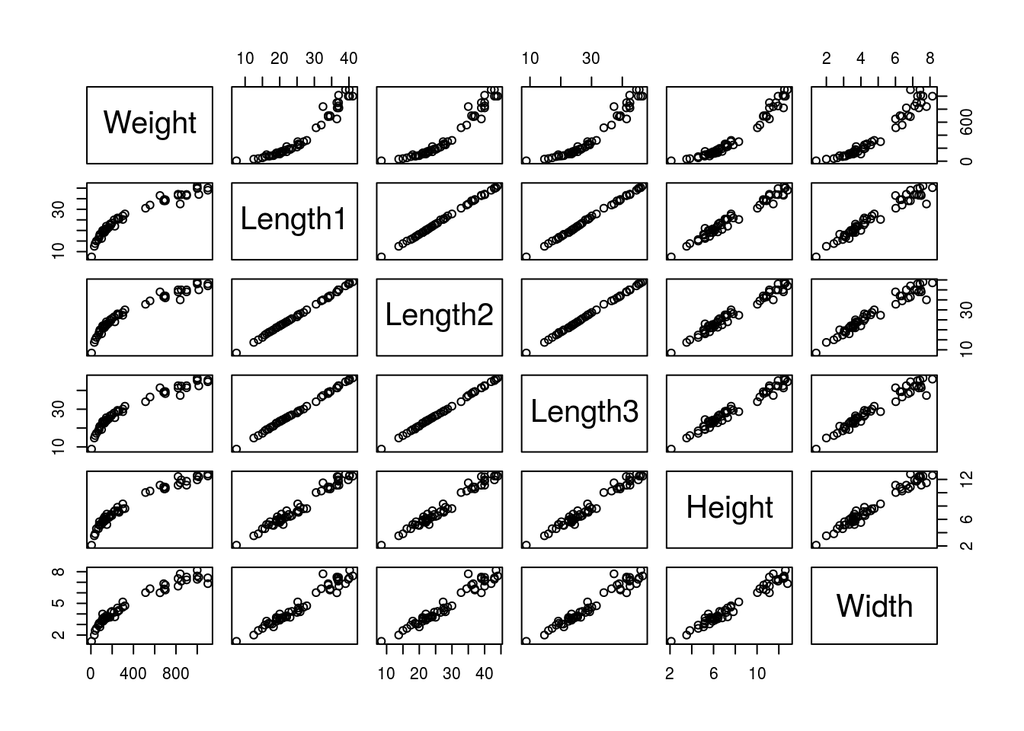

```r
FishiesP=filter(Fishdata, Species == "Perch")
FishiesP = select(FishiesP,-Species)
pairs(FishiesP)
```

#### 2.1.1.1 Best variables with Perch is Height~Width.

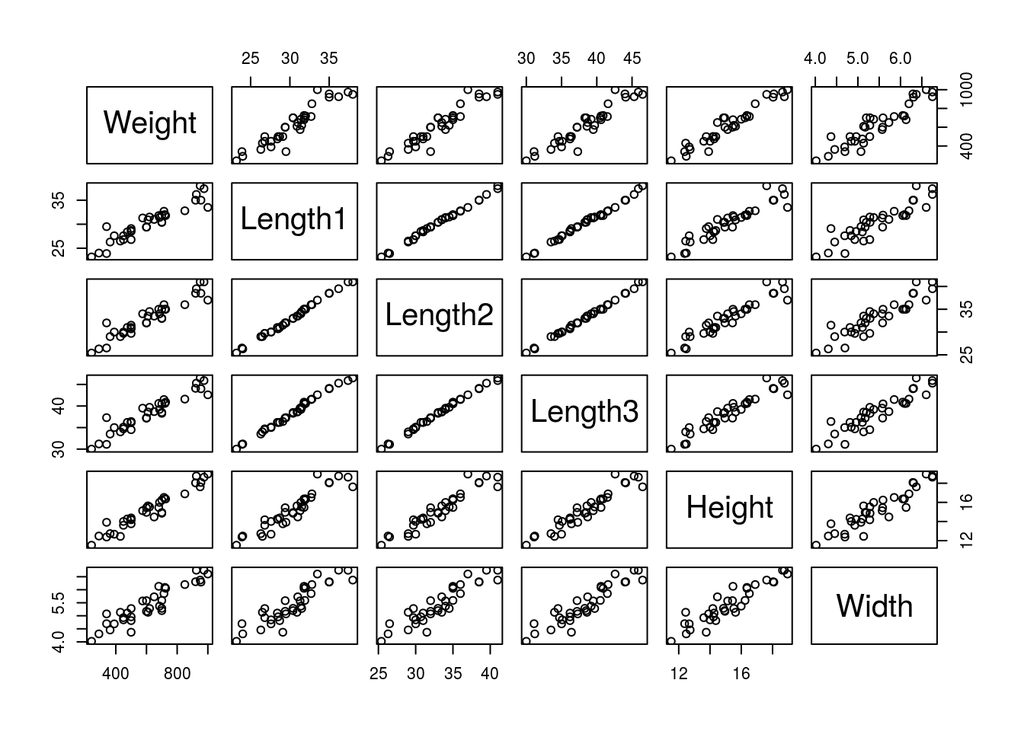

```r
FishiesB=filter(Fishdata, Species == "Bream")
FishiesB = select(FishiesB,-Species)
pairs(FishiesB)
```

#### 2.1.1.2 The best variables for Bream fishes is Length2~Height

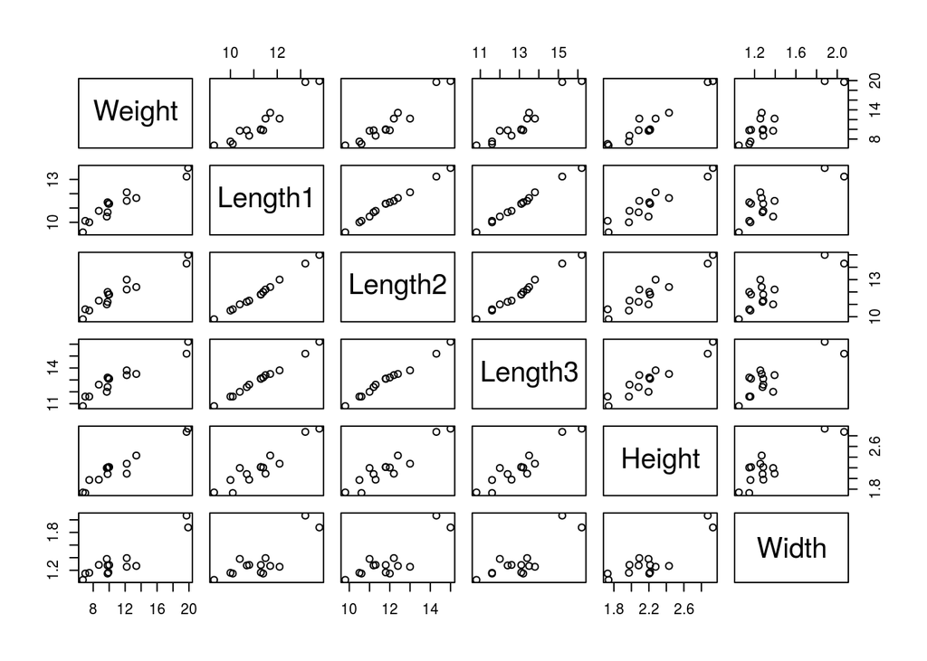

```r
FishiesS=filter(Fishdata, Species == "Smelt")
FishiesS = select(FishiesS,-Species)
pairs(FishiesS)
```

#### 2.1.1.3 The best 2 variables for Smelt is Weight~L2.

### 2.1.2 Numerical Descriptive Results

```r
summary(FishiesP)
```

```
##      Weight          Length1         Length2         Length3
##  Min.   :   5.9   Min.   : 7.50   Min.   : 8.40   Min.   : 8.80
##  1st Qu.: 120.0   1st Qu.:19.82   1st Qu.:21.82   1st Qu.:23.32
##  Median : 207.5   Median :23.25   Median :25.30   Median :26.75
##  Mean   : 382.2   Mean   :25.74   Mean   :27.89   Mean   :29.57
##  3rd Qu.: 692.5   3rd Qu.:34.12   3rd Qu.:36.62   3rd Qu.:39.08
##  Max.   :1100.0   Max.   :41.10   Max.   :44.00   Max.   :46.60
##      Height           Width
##  Min.   : 2.112   Min.   :1.408
##  1st Qu.: 5.692   1st Qu.:3.525
##  Median : 6.922   Median :4.155
##  Mean   : 7.862   Mean   :4.746
##  3rd Qu.:10.847   3rd Qu.:6.448
##  Max.   :12.800   Max.   :8.142
```

```r
summary(FishiesB)
```

```
##      Weight          Length1         Length2         Length3
##  Min.   : 242.0   Min.   :23.20   Min.   :25.40   Min.   :30.00
##  1st Qu.: 462.5   1st Qu.:28.00   1st Qu.:30.35   1st Qu.:35.65
##  Median : 610.0   Median :30.40   Median :33.00   Median :38.50
##  Mean   : 617.8   Mean   :30.31   Mean   :33.11   Mean   :38.35
##  3rd Qu.: 717.0   3rd Qu.:31.95   3rd Qu.:35.00   3rd Qu.:40.75
##  Max.   :1000.0   Max.   :38.00   Max.   :41.00   Max.   :46.50
##      Height          Width
##  Min.   :11.52   Min.   :4.020
##  1st Qu.:13.96   1st Qu.:4.943
##  Median :14.95   Median :5.280
##  Mean   :15.18   Mean   :5.428
##  3rd Qu.:16.36   3rd Qu.:6.072
##  Max.   :18.96   Max.   :6.750
```

```r
summary(FishiesS)
```

```
##      Weight         Length1         Length2         Length3
##  Min.   : 6.70   Min.   : 9.30   Min.   : 9.80   Min.   :10.80
##  1st Qu.: 8.95   1st Qu.:10.47   1st Qu.:11.05   1st Qu.:12.10
##  Median : 9.85   Median :11.30   Median :11.80   Median :13.10
##  Mean   :11.18   Mean   :11.26   Mean   :11.92   Mean   :13.04
##  3rd Qu.:12.20   3rd Qu.:11.65   3rd Qu.:12.35   3rd Qu.:13.47
##  Max.   :19.90   Max.   :13.80   Max.   :15.00   Max.   :16.20
##      Height          Width
##  Min.   :1.728   Min.   :1.048
##  1st Qu.:2.004   1st Qu.:1.161
##  Median :2.200   Median :1.273
##  Mean   :2.209   Mean   :1.340
##  3rd Qu.:2.261   3rd Qu.:1.356
##  Max.   :2.932   Max.   :2.067
```

```r
library(leaps)
regsubsets.out <-
    regsubsets(Weight ~ .,
               data = FishiesP,
               nbest = 1,       # 1 best model for each number of predictors
               nvmax = NULL,    # NULL for no limit on number of variables
               force.in = NULL, force.out = NULL,
               method = "exhaustive")

summary.out <- summary(regsubsets.out)
as.data.frame(summary.out$outmat)
```

```
##          Length1 Length2 Length3 Height Width
## 1  ( 1 )                              *
## 2  ( 1 )                              *     *
## 3  ( 1 )                       *      *     *
## 4  ( 1 )               *       *      *     *
## 5  ( 1 )       *       *       *      *     *
```

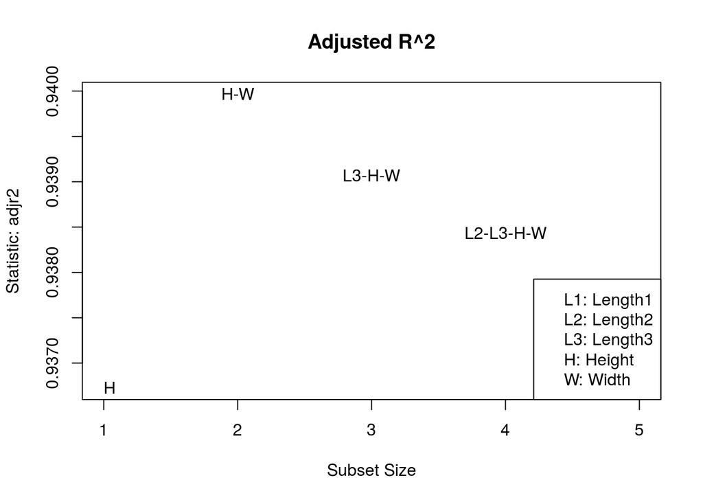

```r
library(car)
subsets(regsubsets.out,statistic="adjr2",legend="bottomright",main="Adjusted R^2")
```

#### 2.1.2.1 The best is Height and Width for Perch.

```r
library(leaps)
regsubsets.out <-
    regsubsets(Weight ~ .,
               data = FishiesB,
               nbest = 1,       # 1 best model for each number of predictors
               nvmax = NULL,    # NULL for no limit on number of variables
               force.in = NULL, force.out = NULL,
               method = "exhaustive")

summary.out <- summary(regsubsets.out)
as.data.frame(summary.out$outmat)
```

```
##          Length1 Length2 Length3 Height Width
## 1  ( 1 )                              *
## 2  ( 1 )               *              *
## 3  ( 1 )       *                      *     *
## 4  ( 1 )               *       *      *     *
## 5  ( 1 )       *       *       *      *     *
```

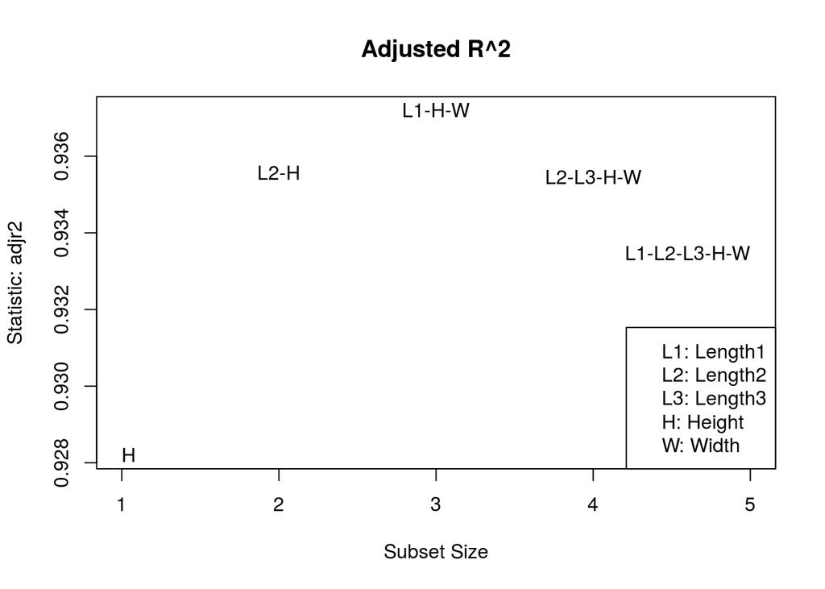

```r
library(car)
subsets(regsubsets.out,statistic="adjr2",legend="bottomright",main="Adjusted R^2")
```

#### 2.1.2.2 The best variables for Bream to find weight is Length2 and Height.

```r
library(leaps)
regsubsets.out <-
    regsubsets(Weight ~ .,
               data = FishiesS,
               nbest = 1,       # 1 best model for each number of predictors
               nvmax = NULL,    # NULL for no limit on number of variables
               force.in = NULL, force.out = NULL,
               method = "exhaustive")

summary.out <- summary(regsubsets.out)
as.data.frame(summary.out$outmat)
```

```
##          Length1 Length2 Length3 Height Width
## 1  ( 1 )               *
## 2  ( 1 )               *                    *
## 3  ( 1 )               *              *     *
## 4  ( 1 )       *       *              *     *
## 5  ( 1 )       *       *       *      *     *
```

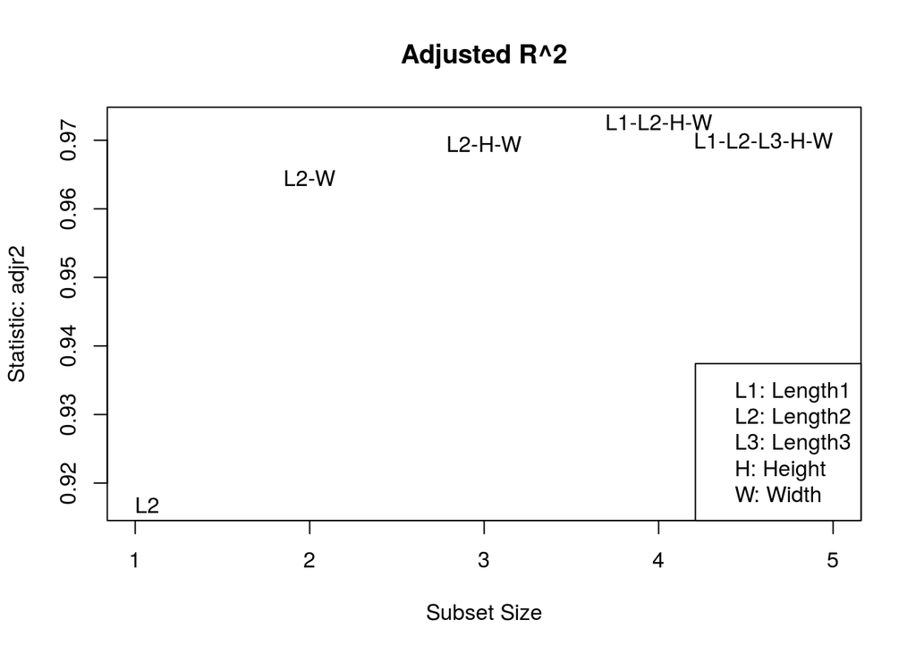

```r
library(car)
subsets(regsubsets.out,statistic="adjr2",legend="bottomright",main="Adjusted R^2")
```

#### 2.1.2.3 The best to variables is Length2 and Width.

## 2.2 Inferential Results

```r
Perchmodel=lm(Weight~Height+Width,data=FishiesP)
summary(Perchmodel)
```

```
##
## Call:
## lm(formula = Weight ~ Height + Width, data = FishiesP)
##
## Residuals:
##     Min      1Q  Median      3Q     Max
## -143.98  -52.99  -21.83   44.53  285.96
##
## Coefficients:
##             Estimate Std. Error t value Pr(>|t|)
## (Intercept)  -536.00      33.38 -16.058  < 2e-16 ***
## Height         74.77      21.70   3.446  0.00112 **
## Width          69.62      35.19   1.978  0.05309 .
## ---
## Signif. codes:  0 '***' 0.001 '**' 0.01 '*' 0.05 '.' 0.1 ' ' 1
##
## Residual standard error: 85.17 on 53 degrees of freedom
## Multiple R-squared:  0.9421, Adjusted R-squared:   0.94
## F-statistic: 431.6 on 2 and 53 DF,  p-value: < 2.2e-16
```

#### 2.2.0.1 Adjusted R-Squared for Perch is 0.94.

```r
Breammodel=lm(Weight~Length2+Height,data=FishiesB)
summary(Breammodel)
```

```
##
## Call:
## lm(formula = Weight ~ Length2 + Height, data = FishiesB)
##
## Residuals:
##      Min       1Q   Median       3Q      Max
## -168.537  -24.862   -5.562   22.370  107.114
##
## Coefficients:
##              Estimate Std. Error t value Pr(>|t|)
## (Intercept) -1013.115     78.150 -12.964 2.79e-14 ***
## Length2        16.348      7.485   2.184   0.0364 *
## Height         71.769     14.902   4.816 3.39e-05 ***
## ---
## Signif. codes:  0 '***' 0.001 '**' 0.01 '*' 0.05 '.' 0.1 ' ' 1
##
## Residual standard error: 53.1 on 32 degrees of freedom
## Multiple R-squared:  0.9394, Adjusted R-squared:  0.9356
## F-statistic: 247.8 on 2 and 32 DF,  p-value: < 2.2e-16
```

#### 2.2.0.2 Adjusted R-square for Bream fishes is 0.9356.

```r
Smeltmodel=lm(Weight~Length2+Width,data=FishiesS)
summary(Smeltmodel)
```

```
##
## Call:
## lm(formula = Weight ~ Length2 + Width, data = FishiesS)
##
## Residuals:
##      Min       1Q   Median       3Q      Max
## -1.03599 -0.45245 -0.04809  0.17169  1.75596
##
## Coefficients:
##             Estimate Std. Error t value Pr(>|t|)
## (Intercept) -18.1301     2.0214  -8.969 2.17e-06 ***
## Length2       1.8184     0.2752   6.608 3.82e-05 ***
## Width         5.6938     1.3751   4.141  0.00164 **
## ---
## Signif. codes:  0 '***' 0.001 '**' 0.01 '*' 0.05 '.' 0.1 ' ' 1
##
## Residual standard error: 0.7783 on 11 degrees of freedom
## Multiple R-squared:   0.97,  Adjusted R-squared:  0.9645
## F-statistic: 177.7 on 2 and 11 DF,  p-value: 4.231e-09
```

#### 2.2.0.3 Adjusted R-squared for Smelt is 0.9645.

# 3 Discussion and Conclusion

To predict the weight of fishes (Perch,Bream, and Smelt), we found two variables in each fishes that has a correlation of the two variables and the weight it may be at.  
For Perch, we used the two variables Height and Width to predict weight. The Adjusted variable is 0.94 also.  
For Bream and Smelt we used the same variable “Length2” and used Height and Width respectively. The Adjusted variable for Bream was 0.9356 and for Smelt was 0.9645.  
With this we found that the different fishes may use 1 of the same variables but more likely each fish uses their unique variable combinations to allow us to predict weight.